# Lasso estimation

ST310

## Lasso simulations

### Functions to simulate data

The functions below do the following.

1. Simulate a sparse high-dimensional linear model
   $$\mathbf y = \mathbf X \beta + \varepsilon, \text{ for } \varepsilon \sim
   N(0, \sigma^2 I)$$
2. Fit ridge regression on a grid of $\lambda$ values
3. Iterate over multiple realizations of $\varepsilon$
4. Plot the MSE of estimated coefficients as a function of $\lambda$, with one line for each iterate

$$\text{MSE}(\hat \beta_\text{ridge}(\lambda))$$

In a real dataset we would only see one of these lines, but the simulation gives us a sense of how the performance could vary depending on the randomness of the noise in the linear model. (Optional: change the functions so you can also specify the noise level and see how larger noise variance affect the results)

```r
instance <- function(X, L, n, p, beta, mu) {
  # Add noise to signal
  Y <- mu + rnorm(n)
  y <- Y - mean(Y)
  # Fit model with glmnet
  ridge_fit <- glmnet(X, y, standardize = TRUE, intercept = FALSE, alpha = 0, lambda = L)
  # Extract estimate coefficients
  beta_mat <- coef(ridge_fit)[-1, ]
  # Compute MSE using true beta
  MSEs <- apply(beta_mat, 2, function(beta_hat) sum((beta_hat - beta)^2))
  out <- as.numeric(MSEs)
  names(out) <- L
  out
}
```

```r
high_dim_MSE_MC <- function(n, p, instances = 10) {
  ## Generating signal
  # A random sparse coefficient vector
  beta <- rnorm(p) * rpois(p, 1) * rbinom(p, 1, .5)
  # Fixed design matrix and mean
  X <- matrix(rnorm(n*p), nrow = n)
  mu <- X %*% beta
  # Lambda grid
  L <- exp(seq(
    from = log(max(n, p, sum(beta^2))),
    to = log(1e-3), length.out = n))
  ## Generate many noise instances
  # tidyverse version of replicate()
  output <- tibble(inst = 1:instances) %>%
    mutate(MSEs = map(inst, ~instance(X, L, n, p, beta, mu)))
  ## Transform output to long data.frame
  out_df <- output %>%
    unnest_longer("MSEs") %>%
    mutate(MSEs_id = as.numeric(MSEs_id))
  names(out_df) <- c("instance", "MSE", "lambda")
  ## Plot results
  out_df %>%
  ggplot(aes(lambda, MSE)) +
    ggtitle(bquote(
      list(sparsity == .(sum(beta != 0)),
           abs(abs(beta))^2 == .(round(sum(beta^2), 2)))
    )) +
    geom_line(aes(group = factor(instance)),
            alpha = .2,
            show.legend = FALSE) +
    scale_x_log10()
}
```

Delete the `set.seed()` line and run the function a few times to see the results.

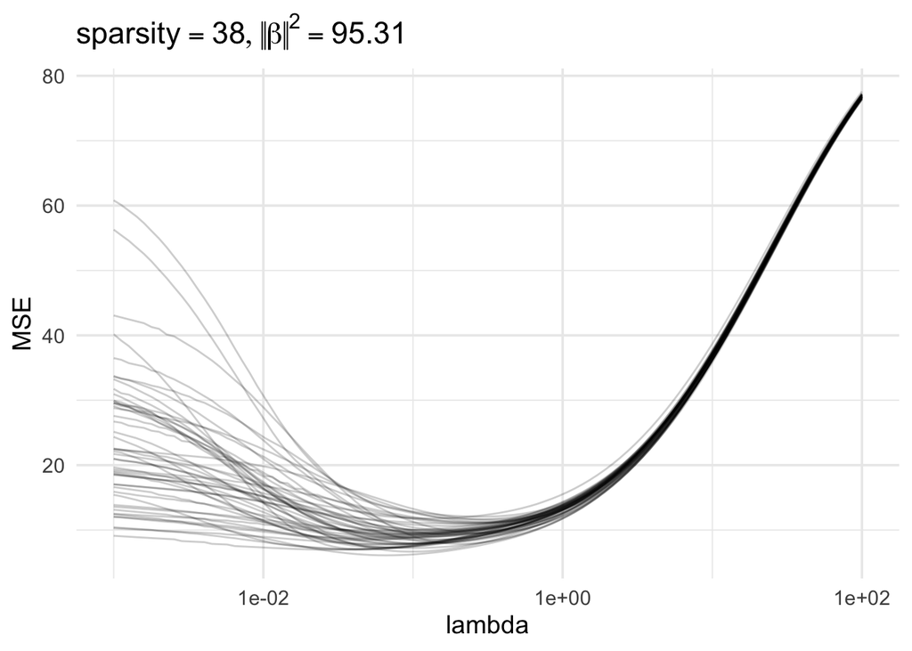

```r
set.seed(123456789) # delete this line
high_dim_MSE_MC(n = 100, p = 100, instances = 50)
```

### Performance of the lasso

Copy/paste and modify the previous functions and use them to experiment with the lasso

- Choose some metric to plot, like MSE of $\hat \beta_\text{lasso}(\lambda)$, out of sample prediction accuracy, or true/false positive rates of selected variables.
- Experiment with the parameters, $n$, $p$, sparsity, or making the design matrix $X$ have correlated columns, to see how the performance changes